# PYTHON TUTORIAL

### 4.1.4 Dictionary

- 1.Introduction
- 2.Create a dictionary in Python
- 3.Add Elements to a Python Dictionary
- 4.Change Value of Dictionary
- 5.Removing elements from Dictionary
- 6.Accessing Elements from Dictionary
- 7.Python Dictionary Methods
- 8.Iterating Through a Dictionary
- 9.List vs Tuples vs Dictionary

#### 1.Introduction

Dictionary in Python is defined inside curly braces ‘{ }’. Each key is separated by a from its value by a colon (:) and to access and assign value, indexing operator ‘[ ]’ is used.

If we have the key, we can retrieve its value anytime, however vice-versa doesn’t work. Hence Python dictionaries are used and optimized for retrieving data when the key is known. In the below figure we have a dictionary name py_dict holding key and value

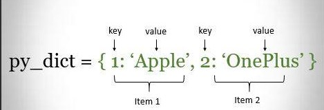

###### Understanding keys:

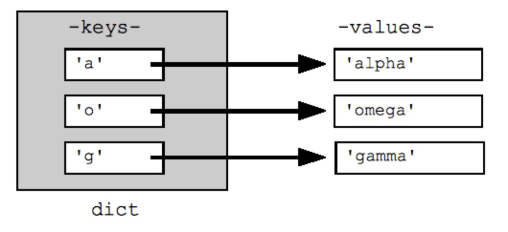

#### 2.Create a dictionary in Python

- a)Curly bracket syntax
- b)Using dict() constructor

##### a) Curly bracket syntax

```python
#Example 1
empty_dict = {}
print(empty_dict)
print(type(empty_dict))
#Note the dictionary is printed and the class of empty_dict is dictionary
```

```
{}
<class 'dict'>
```

```python
#Example 2:Placing a comma-separated items (key: value) pairs within the braces {} adds initial items to the dictionary.
capital_city = {"Nepal": "Kathmandu", "Italy": "Rome", "England": "London"}
print(capital_city)
```

```
{'Nepal': 'Kathmandu', 'Italy': 'Rome', 'England': 'London'}
```

###### Code Explantion

In the above example, we have created a dictionary named capital_city. Here,

- Keys are "Nepal", "Italy", "England"
- Values are "Kathmandu", "Rome", "London"
- Note: Here, keys and values both are of string type. We can also have keys and values of different data types.

##### b) Using dict() constructor

The dict() constructor build dictionaries directly from sequences of (key: value) pairs. In order to create an empty dictionary, you can call dict() with no arguments.

```python
#Example 1
capital_dict = dict()
print(capital_dict)
```

```
{}
```

```python
#Example 1
capital_dict = dict( India="New Delhi",
                     Pakistan="Islamabad",
                     Nigeria="Abuja",
                     Zambia="Lusaka")
print(capital_dict)
```

```
{'India': 'New Delhi', 'Pakistan': 'Islamabad', 'Nigeria': 'Abuja', 'Zambia': 'Lusaka'}
```

#### 3.Add Elements to a Python Dictionary

```python
We can add elements to a dictionary using the name of the dictionary with []. For example,
```

```python
capital_city = {"Nepal": "Kathmandu", "England": "London"}
print("Initial Dictionary: ",capital_city)   #Output Initial Dictionary:  {'Nepal': 'Kathmandu', 'England': 'London'}

capital_city["Japan"] = "Tokyo"
print("Updated Dictionary: ",capital_city) #Output Updated Dictionary:  {'Nepal': 'Kathmandu', 'England': 'London', 'Japan': 'Tokyo'}
```

```
Initial Dictionary:  {'Nepal': 'Kathmandu', 'England': 'London'}
Updated Dictionary:  {'Nepal': 'Kathmandu', 'England': 'London', 'Japan': 'Tokyo'}
```

###### Code Explanation

The code creates a dictionary named capital_city with two initial key-value pairs: "Nepal": "Kathmandu" and "England": "London". The print() statement is then used to display the initial dictionary.

Next, a new key-value pair "Japan": "Tokyo" is added to the capital_city dictionary using dictionary indexing. Finally, another print() statement is used to display the updated capital_city dictionary. The output shows the initial dictionary with two key-value pairs, followed by the updated dictionary with the new key-value pair "Japan": "Tokyo" added to it.

#### 4.Change Value of Dictionary

We can also use [] to change the value associated with a particular key. For example,

```python
student_id = {111: "Eric", 112: "Kyle", 113: "Butters"}
print("Initial Dictionary: ", student_id)

student_id[112] = "Stan"
print("Updated Dictionary: ", student_id)
```

```
Initial Dictionary:  {111: 'Eric', 112: 'Kyle', 113: 'Butters'}
Updated Dictionary:  {111: 'Eric', 112: 'Stan', 113: 'Butters'}
```

###### Code Explanation

The code creates a dictionary named student_id with three initial key-value pairs. The initial dictionary is displayed using print().

Then, the value associated with the key 112 in the student_id dictionary is updated from "Kyle" to "Stan" using dictionary indexing. Finally, the updated student_id dictionary is displayed again using print(), showing the change in the value associated with the key 112.

#### 5.Removing Value of Dictionary

We use the del statement to remove an element from the dictionary. For example,

```python
student_id = {111: "Eric", 112: "Kyle", 113: "Butters"}
print("Initial Dictionary: ", student_id)

del student_id[111]
print("Updated Dictionary ", student_id)
```

```
Initial Dictionary:  {111: 'Eric', 112: 'Kyle', 113: 'Butters'}
Updated Dictionary  {112: 'Kyle', 113: 'Butters'}
```

###### Code Explanation

Here, we have created a dictionary named student_id. Notice the code,

del student_id[111] The del statement removes the element associated with the key 111.

#### 6.Accessing Elements from Dictionary

##### 1.Using Square brackets

To access dictionary elements, you can use square brackets along with the key to obtain its value

```python
#example 1:
GDP_2017 = {"India": 6.6, "Zambia": 4.1, "Nigeria": 0.8,"Peru":2.5, "Ghana": 8.5}
print(GDP_2017["India"])   #Output:6.6
#Note:If the given key does not exist in the dictionary, Python raises a Key Error exception.
#This will result in error -> print(GDP_2017["Bhutan"])
```

```
6.6
```

##### 2.get(key , default ) method

The get(key, default) method is a built-in method in Python dictionaries that allows you to retrieve the value associated with a specific key. If the key is not present in the dictionary, it returns a default value that you can specify. The method takes two arguments:

key: The key for which you want to retrieve the value from the dictionary. default: The value to be returned if the key is not present in the dictionary. This is an optional parameter, and if not provided, it defaults to None. Here's an example to illustrate the usage of the get(key, default) method:

```python
# Define a dictionary
fruits = {'apple': 3, 'banana': 5, 'cherry': 2}

# Retrieve value for a valid key
apple_count = fruits.get('apple', 0)
print("Number of apples:", apple_count)  # Output: Number of apples: 3

# Retrieve value for an invalid key
orange_count = fruits.get('orange', 0)
print("Number of oranges:", orange_count)  # Output: Number of oranges: 0

# Retrieve value for an invalid key with a default value specified
grape_count = fruits.get('grape', -1)
print("Number of grapes:", grape_count)  # Output: Number of grapes: -1
```

[output not shown]

##### Code Explanation

However, 'orange' and 'grape' are not valid keys in the fruits dictionary, so we get the default values of 0 and -1 respectively, which we specified as the second argument to the get() method.

#### 6.Python Dictionary Methods

Methods that are available with a dictionary are tabulated below. Some of them have already been used in the above examples.

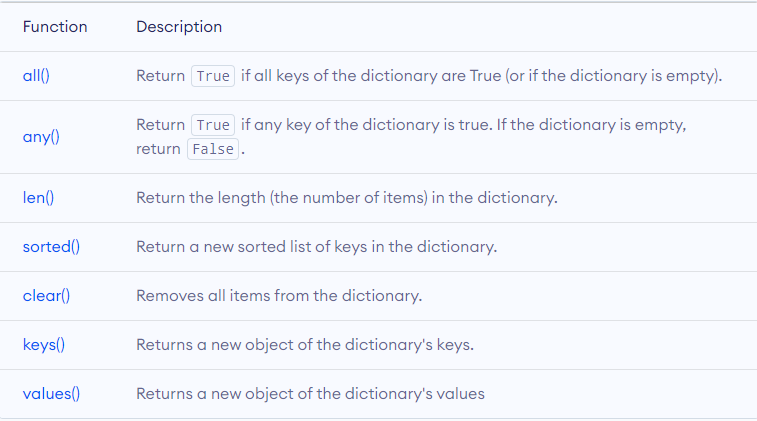

#### 8.Iterating in Dictionary

Iterating through a dictionary in Python allows you to loop over its keys, values, or both, and perform operations on them. There are several ways to iterate through a dictionary in Python:

###### a.Looping through keys:

```python
student_id = {111: "Eric", 112: "Kyle", 113: "Butters"}
for key in student_id.keys():
    print(key)
#Note we can use a for loop to iterate through the keys of a dictionary using the keys() method.
```

```
111
112
113
```

###### b.Looping through values:

```python
 #Note: We can use a for loop to iterate through the values of a dictionary using the values() method.
```

```python
student_id = {111: "Eric", 112: "Kyle", 113: "Butters"}
for value in student_id.values():
    print(value)
```

```
Eric
Kyle
Butters
```

###### c.Looping through key-value pairs:

```python
#We can use a for loop to iterate through the key-value pairs of a dictionary using the items() method. Here's an example:
```

```python
student_id = {111: "Eric", 112: "Kyle", 113: "Butters"}
for key, value in student_id.items():
    print(key, value)
```

```
111 Eric
112 Kyle
113 Butters
```

##### 9.List vs Tuples vs Dictionary

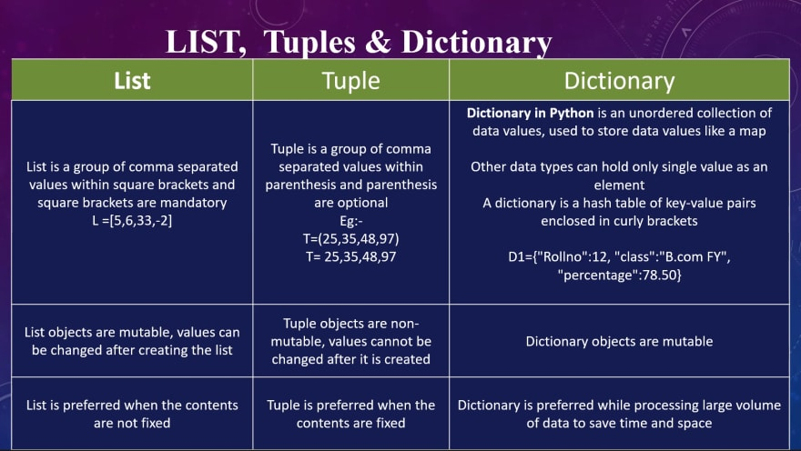

### 4.1.5 Operators

Operators are special symbols that perform operations on variables and values. For example,

```python
#print(5 + 6)   # 11  will print value 11
```

#### Types of Python Operators

Here's a list of different types of Python operators that we will learn in this tutorial.

- 1. Arithmetic operators
- 1. Assignment Operators
- 1. Comparison Operators
- 1. Logical Operators
- 1. Bitwise Operators
- 1. Identity Operators

[figure not shown]

[figure not shown]

The operators along with the code excecution is shown below

```python
#Operator 1  "=" : This is the basic assignment operator that assigns the value on the right to the variable on the left.
x = 5
# This assigns the value 5 to the variable x.
#-----------------------------------------------------------------------------------------------------------------------
# Operator 2 "+=" : This operator adds the value on the right to the variable on the left and assigns the result to the left variable. For example:
x = 5
x += 3   # equivalent to x = x + 3
print(x)   # Output: 8
# This adds 3 to the value of x (which is 5), resulting in a new value of 8 for x.
#-----------------------------------------------------------------------------------------------------------------------

# Operator 3"-=" : This operator subtracts the value on the right from the variable on the left and assigns the result to the left variable. For example:
x = 5
x -= 2   # equivalent to x = x - 2
print(x)   # Output: 3

# This subtracts 2 from the value of x (which is 5), resulting in a new value of 3 for x.
#-----------------------------------------------------------------------------------------------------------------------

# Operator 3 "*=" : This operator multiplies the value on the right with the variable on the left and assigns the result to the left variable. For example:

x = 5
x *= 2   # equivalent to x = x * 2
print(x)   # Output: 10
# This multiplies the value of x (which is 5) by 2, resulting in a new value of 10 for x.
#-----------------------------------------------------------------------------------------------------------------------

# Operator 4 "/=" : This operator divides the value on the left by the value on the right and assigns the result to the left variable. For example:

x = 10
x /= 2   # equivalent to x = x / 2
print(x)   # Output: 5.0
# This divides the value of x (which is 10) by 2, resulting in a new value of 5.0 for x.
#-----------------------------------------------------------------------------------------------------------------------

#Operator 4 "%=" : This operator calculates the remainder when the value on the left is divided by the value on the right and assigns the result to the left variable. For example:

x = 10
x %= 3   # equivalent to x = x % 3
print(x)   # Output: 1
# This calculates the remainder when 10 is divided by 3, resulting in a new value of 1 for x.

#-----------------------------------------------------------------------------------------------------------------------

# Operator 5 "**=" : This operator raises the value on the left to the power of the value on the right and assigns the result to the left variable. For example:
x = 2
x **= 3   # equivalent to x = x ** 3
print(x)   # Output: 8
# This raises the value of x (which is 2) to the power of 3, resulting in a new value of 8 for x.
```

```
8
3
10
5.0
1
8
```

##### 3.Comparison operators

Comparison operators compare the values of the two operands and return a true or false Boolean value in accordance. The following table lists the comparison operators.

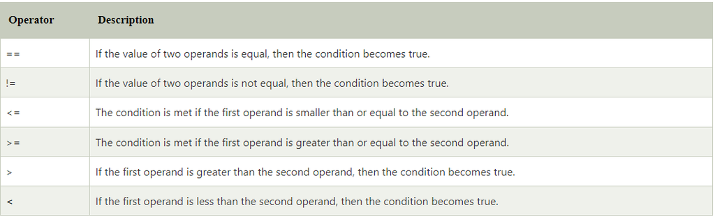

```python
a = 5
b = 2

# equal to operator
print('a == b =', a == b)
# == operator to check if a is equal to b. Since a is not equal to b, the result of this comparison is False.


# not equal to operator
print('a != b =', a != b)
# Since a is not equal to b, the result of this comparison is True.

# greater than operator
print('a > b =', a > b)
# > operator to check if a is greater than b. Since a is greater than b, the result of this comparison is True.


# less than operator
print('a < b =', a < b)
#< operator to checks if a is less than b. Since a is not less than b, the result of this comparison is False.


# greater than or equal to operator
print('a >= b =', a >= b)
# >= operator to check if a is greater than or equal to b. Since a is greater than b, the result of this comparison is True.

# less than or equal to operator
print('a <= b =', a <= b)
#<= operator to check if a is less than or equal to b. Since a is not less than b, the result of this comparison is False
```

```
a == b = False
a != b = True
a > b = True
a < b = False
a >= b = True
a <= b = False
```

##### 4.Logical operators

The assessment of expressions to make decisions typically makes use of the logical operators. The following logical operators are supported by Python.

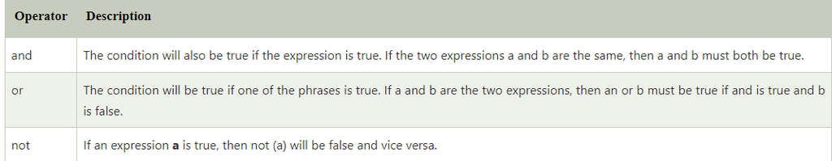

```python
# logical AND
print(True and True)     # Output is True
print(True and False)    # Output is False

# logical OR
print(True or False)     # Output is True

# logical NOT
print(not True)          # Output is False
```

```
True
False
True
False
```

###### Code Explanation

The first operation uses the and operator to perform logical AND between two boolean values True and True. Since both operands are True, the result is True.

The second operation uses the and operator to perform logical AND between True and False. Since one of the operands is False, the result is False.

The third operation uses the or operator to perform logical OR between True and False. Since one of the operands is True, the result is True.

The fourth operation uses the not operator to perform logical NOT on True. Since the operand is True, the result is False

##### 5 Identity Operator

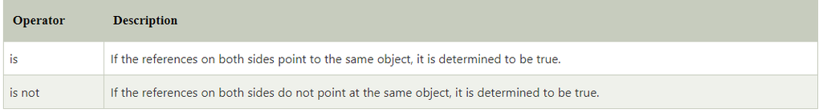

```python
x1 = 5
y1 = 5
x2 = 'Hello'
y2 = 'Hello'
x3 = [1,2,3]
y3 = [1,2,3]

print(x1 is not y1)  # prints False

print(x2 is y2)  # prints True

print(x3 is y3)  # prints False
```

```
False
True
False
```

### 4.1.6 Decision making

Decision making statements in python are an essential tool for any programmer. They allow any program to make intelligent and informed decisions by evaluating information before executing that particular code. Decision making statements can direct a program to execute on the based of instructions if a certain condition is True or another if it's False. Different decision making structures can be used such as if statements, else-if statements, and nested if else statements for decision making in python programming language. Each decision structure has its own benefits and applications; however, decision making statements provide an invaluable tool for programming complex conditions in Python.

##### Types of decision-making in python

There are three types of decision making statements in python language, those are

1. If statements in python
2. If else statement in python
3. Nested if else statement in python

###### 1. If statements

if statement is the most simple form of decision-making statement. It takes an expression and checks if the expression evaluates to True then the block of code in if statement will be executed.

If the expression evaluates to False, then the block of code is skipped.

```python
if ( expression ):
  Statement 1
  Statement 2
  .
  Statement n
```

```python
#Example 1
a = 20
b = 20
if ( a == b ):
  print( 'a and b are equal')
print('If block ended')
```

```
a and b are equal
If block ended
```

```python
#Example 2
num = 5
if ( num >= 10):
  print('num is greater than 10')
print('if block ended')
```

```
if block ended
```

###### Code Explanation

In example 1, we see that the condition a==b evaluates to True. Therefore, the block of code inside if statement is executed.

In example 2, the condition evaluates to False, therefore, the print statement was not executed and the only statement that got executed was because it was outside the if block.

Note: Don’t forget to add a colon(:) after if statement and indent the statements properly that are executed when a condition is True.

###### 2. If else statements

if-else statement checks the expression and executes the if block when the expression is True otherwise it will execute the else block of code. The else block should be right after if block and it is executed when the expression is False.

###### Syntax

if( expression )

```
Statement
```

else:

```
Statement
```

```python
#Example 1
number1 = 20 ; number2 = 30
if(number1 >= number2 ):
  print('number 1 is greater than number 2')
else:
  print('number 2 is greater than number 1')
```

```
number 2 is greater than number 1
```

```python
#Example2 :
#Note: Only one else statement is followed by an if statement. If you use two else statements after an if statement, then you get the following error.
# if (5>10):
#   print(5)
# else:
#   print(10)
# else:
#   print('End')

#The above code will result in error
```

###### 3. Nested if else statements

Nested if else statements in python enable complex decisions to be coded into a single statement. Nested if else statements serve as an effective decision-making tool in python programming by allowing developers to code any number of decisions or conditions within an if else statement. Depending on the output of the conditional checks, nested if else statements can take one of several paths, directing the program towards different outcomes. Nested if else statements can help keep high levels of complexity from escalating too quickly and make the code easier to read and troubleshoot.

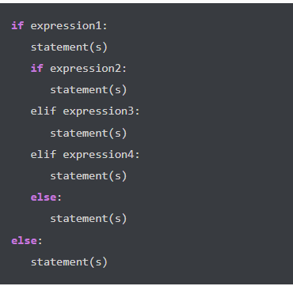

```python
var = 100
if var < 200:
   print ("Expression value is less than 200")
   if var == 150:
      print ("Which is 150")
   elif var == 100:
      print ("Which is 100")
   elif var == 50:
      print( "Which is 50")
   elif var < 50:
      print ("Expression value is less than 50")
else:
   print( "Could not find true expression")
```

```
Expression value is less than 200
Which is 100
```

Below is the summary of execution of the code flow for if ,if-else,Nested if statement

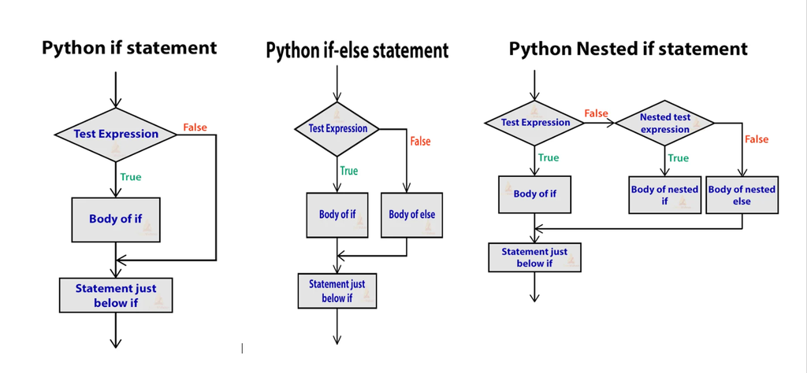

### 4.1.7 Loops

In a programming language, a loop is a statement that contains instructions that continually repeat until a certain condition is reached.

Loops help us remove the redundancy of code when a task has to be repeated several times. With the use of loops, we can cut short those hundred lines of code to a few. Suppose you want to print the text “Hello, World!” 10 times. Rather than writing a print statement 10 times, you can use loops by indicating the number of repetitions needed.

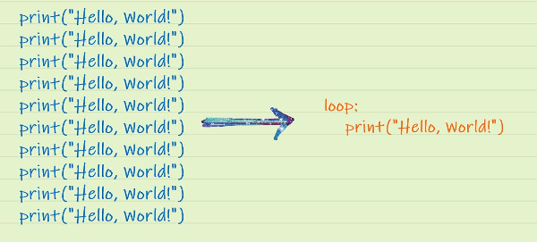

The three types of loops in Python programming are while loop, for loop, and nested loops.But before that lets understand range function

###### Range function

The range() function returns a sequence of numbers between the give range

```python
# create a sequence of numbers from 0 to 3
numbers = range(4)

# iterating through the sequence of numbers
for i in numbers:
    print(i)

# Output:

# 0
# 1
# 2
# 3
```

[output not shown]

###### Syntax of range()

The range() function can take a maximum of three arguments:

- range(start, stop, step)
- The start and step parameters in range() are optional.

```python
# Example 1: range() with Stop Argument
# numbers from 0 to 3 (4 is not included)
# numbers = range(4)
# print(list(numbers))    # [0, 1, 2, 3]

# if 0 or negative number is passed, we get an empty sequence
# numbers = range(-4)
# print(list(numbers))    # []


# Example 2: range() with Start and Stop Arguments
# numbers from 2 to 4 (5 is not included)
# numbers = range(2, 5)
# print(list(numbers))    # [2, 3, 4]

# numbers from -2 to 3 (4 is not included)
# numbers = range(-2, 4)
# print(list(numbers))    # [-2, -1, 0, 1, 2, 3]

# returns an empty sequence of numbers
# numbers = range(4, 2)
# print(list(numbers))    # []
```

###### range() in for Loop

```python
# iterate the loop 5 times
# for i in range(5):
#     print(i, 'Hello')
```

[output not shown]

###### 1.While Loop

Inside the while loop, the statement (code) can be a single statement or a block of statements. The condition may be anything per our requirement, and we can use if, elif, or else in the code. The loop stops running when the condition fails (become false), and the execution will move to the next line of code. Indentation (also called white space) is necessary while defining a statement or code to be executed. Indentation is used to specify program structure and to group statements together in blocks.

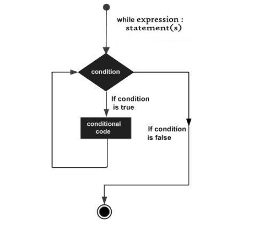

It first checks the condition, executes the conditional code if it is TRUE, and checks the condition again. Program control exits the loop if the condition is FALSE.

```python
count = 0
while count < 5:
    print("Count:", count)
    count += 1
```

```
Count: 0
Count: 1
Count: 2
Count: 3
Count: 4
```

###### Code Explanation

The variable count is initialized with a value of 0.

The while loop begins, and it continues to execute as long as the condition count < 5 is true.

Within each iteration of the loop, the current value of count is printed along with the string "Count:" using the print() function.

After printing, the value of count is incremented by 1 using the count += 1 statement.

The loop repeats until the condition count < 5 becomes false, which means count reaches a value of 5.

Overall, this code will print the numbers 0, 1, 2, 3, and 4, each on a separate line, because the loop runs five times (once for each value of count from 0 to 4).

###### 2.For Loop

A python for loop is used to iterate over data structures like python lists, arrays, dictionaries, sets, tuples or even strings.

Loop statements will be executed for each item of the sequence.

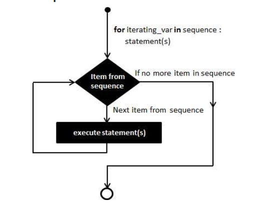

```python
#Example
nums = [10, 20, 30, 40, 50]
for i in nums:
    print(i)
```

```
10
20
30
40
50
```

###### Code Explanation

The list nums is defined with five elements: 10, 20, 30, 40, and 50.

The for loop begins, and in the first iteration, the value of i is set to 10 (the first element of nums).

The value of i (which is 10) is printed.

The loop moves to the next iteration, and now i is set to 20 (the second element of nums).

The value of i (which is 20) is printed.

This process continues for each element in nums, printing each element one by one.

###### 3. Nested Loop

Nested loops mean using a loop inside another loop. We can use any type of loop inside any type of loop. We can use a while loop inside for loop, a for loop inside a while loop, a while loop inside a while loop, or a for loop inside a for loop.

```python
# x = [1, 2]
# y = [4, 5]

# for i in x:
#   for j in y:
#     print(i, j)

# CODE OUTPUT
# 1 4
# 1 5
# 2 4
# 2 5
```

###### Code Explanation

Two lists are defined: x with elements [1, 2], and y with elements [4, 5].

The outer loop starts iterating over each element in x.

For each iteration of the outer loop, the inner loop starts iterating over each element in y.

Inside the inner loop, the code prints the values of i (current element of x) and j (current element of y).

After printing the values, the inner loop moves to the next element in y.

Once the inner loop finishes iterating over all elements in y, the outer loop moves to the next element in x.

The process continues until the outer loop has iterated over all elements in x.

### Python Exercises

##### 1. Python Input and Output Exercise

```python
print('My', 'Name', 'Is', 'James', sep='**')
```

```
My**Name**Is**James
```

##### 2. Python Loop Exercise

Q-1 Print First 10 natural numbers using while loop

Q-2-Write a for loop so that every item in the list is printed.

lst=["koala", "cat", "fox", "panda", "chipmunk", "sloth", "penguin", "dolphin"]

Q-3 Write a for loop which print "Hello!, " plus each name in the list. i.e.: "Hello!, Sam"

lst=["Sam", "Lisa", "Micha", "Dave", "Wyatt", "Emma", "Sage"]

Q-4 Write a for loop that iterates through a string and prints every letter. str="Antarctica"

Q-5 Using a for loop and .append() method append each item with a Dr. prefix to the lst

Q-6 Write a for loop which appends the square of each number to the new list.

Q-7 Write a for loop using an if statement, that appends each number to the new list if it's positive.

Q-8 Write a for loop which appends the type of each element in the first list to the second list.

lst1=[3.14, 66, "Teddy Bear", True, [], {}]

lst2=[]

##### Solutions

Q-1 Print First 10 natural numbers using while loop

```python
# Program 1: Print first 10 natural numbers
# i = 1
# while i <= 10:
#     print(i)
#     i += 1
```

```python
# lst=["koala", "cat", "fox", "panda", "chipmunk", "sloth", "penguin", "dolphin"]
# #Type your answer here.

# for i in lst:
#     print(i)
```

Q-3 Write a for loop which print "Hello!, " plus each name in the list. i.e.: "Hello!, Sam"

```python
lst=["Sam", "Lisa", "Micha", "Dave", "Wyatt", "Emma", "Sage"]
```

```python
# for i in lst:
#     print("Hello!, " + i)
```

Q-4 Write a for loop that iterates through a string and prints every letter.

```python
# str="Antarctica
# for i in str:
#     print(i)
```

Q-5 Using a for loop and .append() method append each item with a Dr. prefix to the lst

```python
# lst1=["Phil", "Oz", "Seuss", "Dre"]
# lst2=[]
# #Type your answer here.
# for i in lst1:
#     lst2.append("Dr. " + i)
```

Q-6 Write a for loop which appends the square of each number to the new list.

```python
# lst1=[3, 7, 6, 8, 9, 11, 15, 25]
# lst2=[]
# for i in lst1:
#     lst2.append(i**2)
```

Q-7 Write a for loop using an if statement, that appends each number to the new list if it's positive.

```python
# lst1=[111, 32, -9, -45, -17, 9, 85, -10]
# lst2=[]
# for i in lst1:
#     if i > 0:
#         lst2.append(i)
```

Q-8 Write a for loop which appends the type of each element in the first list to the second list.

```python
# lst1=[3.14, 66, "Teddy Bear", True, [], {}]
# lst2=[]
# for i in lst1:
#     lst2.append(type(i))
```

##### 3: Python String Exercise

Q-1Assign the string below to the variable in the exercise.

"It's always darkest before dawn."

Q-2 By using first, second and last characters of the string, create a new string. str="It's always darkest before dawn."

Q-3 Replace the (.) with (!) str="It's always darkest before dawn."

Q-4 Reassign str so that, all its characters are lowercase.</br> str="EVERY Strike Brings Me Closer to the Next Home run."

Q-5 Which character occur more often in the string? "a" or "o" ? Print both counts inside the print function.

str="People often say that motivation doesn't last. Well, neither does bathing. That's why we recommend it daily."

Q-6 What is the length of the given string?

str="1.975.000"

##### Solutions

Q-1Assign the string below to the variable in the exercise. "It's always darkest before dawn."

```python
# str = "It's always darkest before dawn."
```

Q-2 By using first, second and last characters of the string, create a new string.

str="It's always darkest before dawn."

```python
# ans_1 = str[0]+str[1]+str[-1]
```

Q-3 Replace the (.) with (!) str="It's always darkest before dawn.

```python
# str = str.replace(".", "!")
```

Q-4 Reassign str so that, all its characters are lowercase.

str="EVERY Strike Brings Me Closer to the Next Home run."

```python
# str = str.lower()
```

Q-5 Which character occur more often in the string? "a" or "o" ? Print both counts inside the print function.

```python
# str="People often say that motivation doesn't last. Well, neither does bathing.That's why we recommend it daily."
# Type your code here.

# ans_1=
# ans_2=
# print("count of a is: ", ans_1, " count of o is: ", ans_2)

# Solution
# ans_1 = str.count("a")
# ans_2 = str.count("o")
```

Q-6 What is the length of the given string?

```python
# str="1.975.000"
# ans_1 = len(str)
```

##### 4:Python List Exercise

Exercise 1: Write a program to create a list with random data types elements List should look like [212, ‘PythonLobby’, 212.3]

Exercise 2: Write a program to print all the elements of a list in single line. num = [203,24,54,34]

Expected output 203 24 54 34

Exercise 3: Write a program to count the number of items stored in a list. num = [23, 34, ‘hello’, 32, 56]

Exercise 4: Write a program to reverse a list in Python. num = [23, 34, ‘hello’, 32, 56]

Exercise 5: Python program to square each element of a list. Given x = [2, 3, 4, 5, 6]

Exercise 6: Python program to append an element to a list. Given num = [23,45,67,8,9] Input: Enter the item to insert: Hello

Exercise 7: Write a program to sum all the elements of a list. Given num = [2,3,2,4,7,8]

Exercise 8: Write a program to append data of the second list to the first list. Given list1 = [23, 24, 25, 26] list2 = [27, 28, 29, 30]

Expected output Result: [23, 24, 25, 26, 27, 28, 29, 30]

##### Solutions

```python
# Exercise 1: Write a program to create a list with random data types elements
# List should look like
# [212, ‘PythonLobby’, 212.3]
#Solution
num = [22,'PythonLobby',212.3]
# print(num)

# printing item with its type
for i in range(len(num)):
    print(num[i])

# Code Explanation: Note we are using the Python loop and the range function
```

[output not shown]

```python
# Exercise 2: Write a program to print all the elements of a list in single line.
# num = [203,24,54,34]
#Solution

num = [23,24,54,34]
for i in range(len(num)):
    print(num[i], end=" ")

#Code explanation

# The given code snippet iterates through a list called num and prints each element on a single line, separated by a space.
```

[output not shown]

```python
# Exercise 3: Write a program to count the number of items stored in a list.
# num = [23, 34, ‘hello’, 32, 56]
# Expected output
# Total count of items are: 5

#Solution
num = [23, 34, 'hello', 32, 56]
count = 0
for i in range(len(num)):
    count += 1
print("Total count of items are:",count)

# Approach 2
print("Total count of items are:",len(num))

#Code explanation
# The both approch counts the number of items in a list called num using two different approaches.

# In the first approach:

# Initialize a variable count to 0.
# Iterate through the indices of the num list using the range(len(num)) function.
# For each iteration, increment the count variable by 1.
# After the loop, print the total count of items by displaying the value of count along with a message.

# In the second approach:

# Directly print the total count of items in the num list using the len(num) function.
# This approach avoids the need for a loop and a separate counting variable.
```

[output not shown]

```python
# Exercise 4: Write a program to reverse a list in Python.
# num = [23, 34, ‘hello’, 32, 56]

# Expected output
# [56, 32, ‘hello’, 34, 23]

#Solution
num = [23, 34, 'hello', 32, 56]
print(num[::-1])

#Code Explanation
# num = [23, 34, 'hello', 32, 56]: This line declares a list called num and initializes it with five elements, including integers (23, 34, 32, 56) and a string ('hello').

# print(num[::-1]): This line prints the elements of the num list in reverse order using slicing notation.

# The [::-1] part specifies a slice that starts from the end of the list and moves backwards with a step size of -1, effectively reversing the order.
# The resulting reversed list is then printed to the console.
```

```
[56, 32, 'hello', 34, 23]
```

```python
# Exercise 5: Python program to square each element of a list.
# Given x = [2, 3, 4, 5, 6]
# Expected output
# Result : 4 9 16 25 36

#Solution
num = [2, 3, 4, 5, 6]

for i in range(len(num)):
    x = num[i]*num[i]
    print(x, end=' ')

#Code Explanation

# The code iterates through the list num,
# calculates the square of each element, and prints the squared values on a single line, separated by a space
```

```
4 9 16 25 36
```

```python
# Exercise 6: Python program to append an element to a list.
# num = [23,45,67,8,9] Input:
# Enter the item to insert: Hello

# Expected output
# Result: [23,45,67,8,9, ‘Hello’]

#Solution
num = [23,45,67,8,9]
x = 'Hello'
num.append(x)

# printing list after insertion
print(num)

#Code Explanation:Note we are appending Hello above using append function
```

```
[23, 45, 67, 8, 9, 'Hello']
```

```python
# Exercise 7: Write a program to sum all the elements of a list.
# Given num = [2,3,2,4,7,8]

# Expected output
# Sum of list items 26
num = [2,3,2,4,7,8]
result = sum(num)

# printing result
print("Sum of list items",result)
#Code Explantion
# The code calculates the sum of all the elements in the num list and prints the result, which in this case is 26.
```

```
Sum of list items 26
```

```python
# Exercise 8: Write a program to append data of the second list to the first list.
# Given list1 = [23, 24, 25, 26]
#list2 = [27, 28, 29, 30]

# Expected output
# Result:
# [23, 24, 25, 26, 27, 28, 29, 30

#Solution
list1 = [23, 24, 25, 26]
list2 = [27, 28, 29, 30]

for i in range(len(list2)):
    list1.append(list2[i])

# printing list 1
print(list1)

#Code Explanation
# The code appends the elements from list2 to list1 and then prints the updated list1, showing all the elements from both lists combined.
```

```
[23, 24, 25, 26, 27, 28, 29, 30]
```